# When Does the Central Limit Theorem Work?

### 3.10.3 Histograms and Q–Q Plots

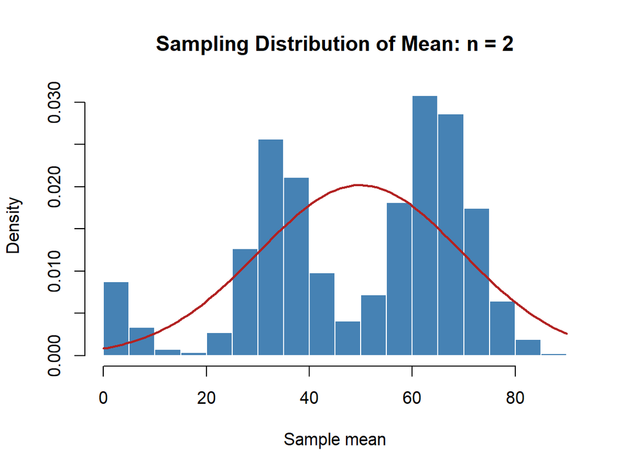

Figure 62: Histogram (left) and normal Q–Q plot (right) of the sample means at selected n.

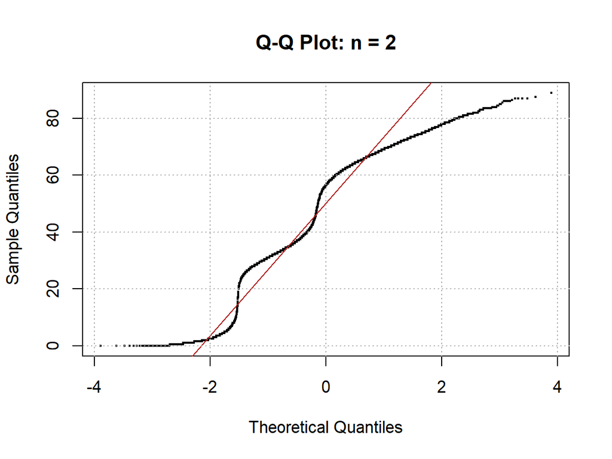

Figure 63: Histogram (left) and normal Q–Q plot (right) of the sample means at selected n.

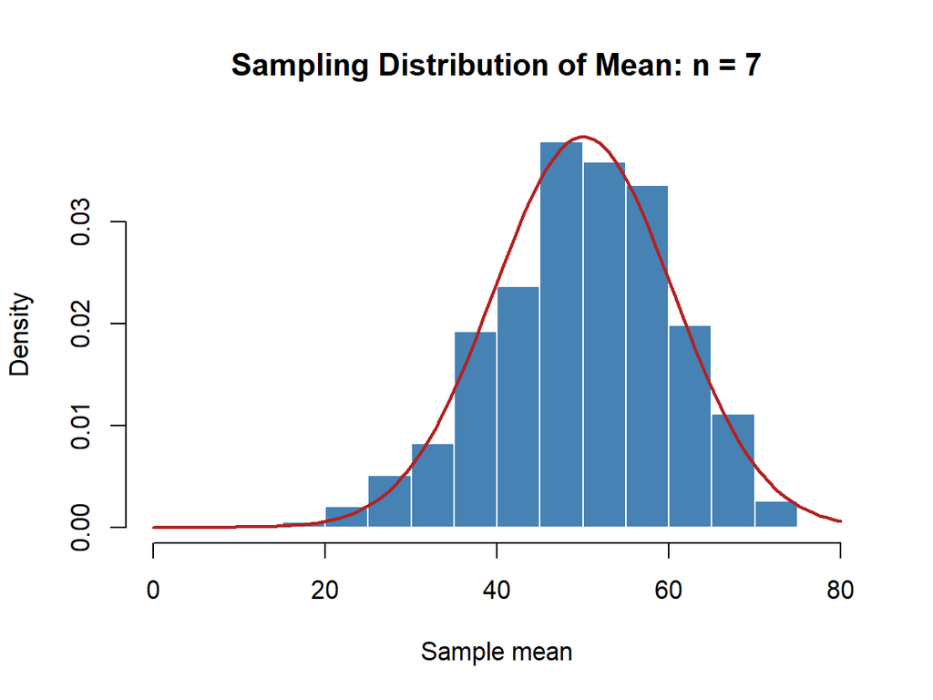

Figure 64: Histogram (left) and normal Q–Q plot (right) of the sample means at selected n.

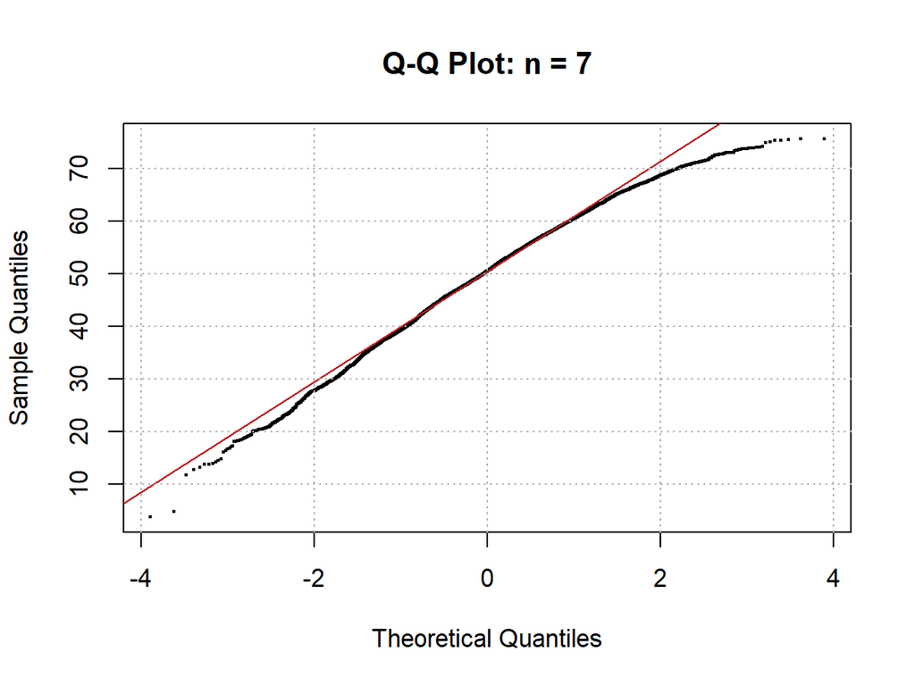

Figure 65: Histogram (left) and normal Q–Q plot (right) of the sample means at selected n.

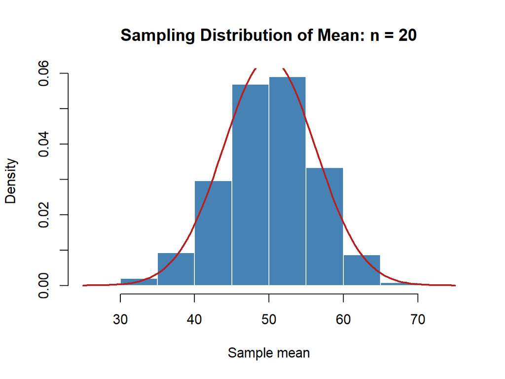

Figure 66: Histogram (left) and normal Q–Q plot (right) of the sample means at selected n.

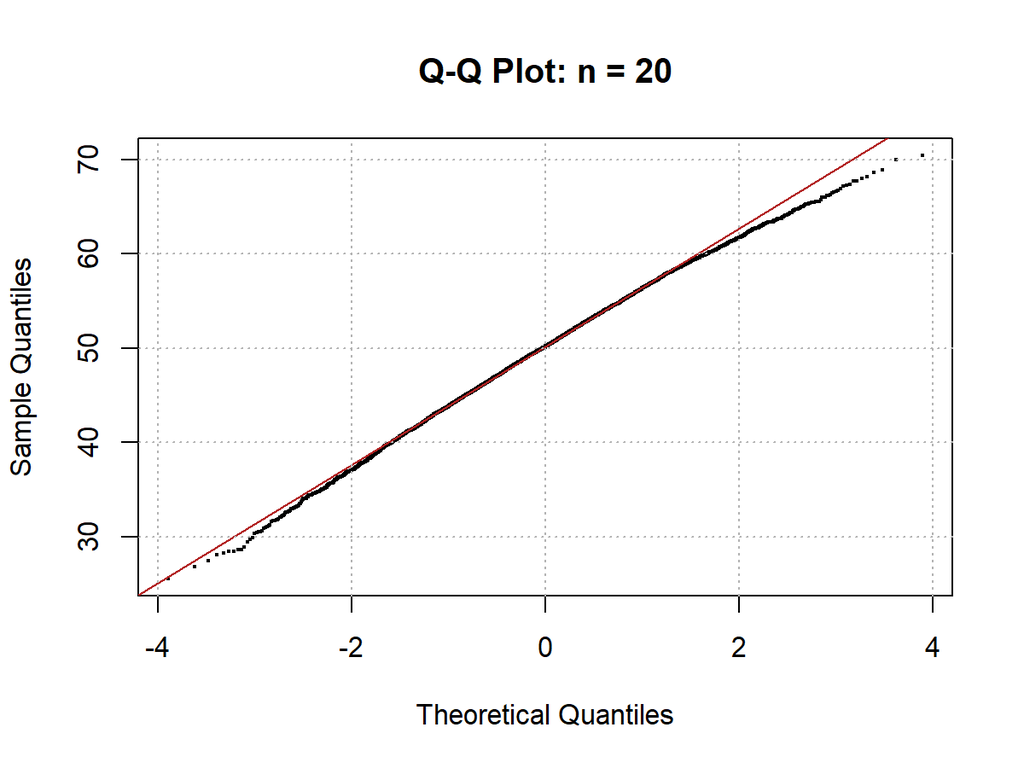

Figure 67: Histogram (left) and normal Q–Q plot (right) of the sample means at selected n.

```r
show_hist_qq("rdeath")
```

### 3.10.4 Formal Test Results

```r
stats_table("rdeath")
```

Table 13: Normality diagnostics for Age at death (bimodal) at the selected n.

| n | Mean | SD (sim. SE) | Skew | Kurt | Shapiro–Wilk W | Shapiro–Wilk p | Lilliefors (KS) D | Lilliefors (KS) p | Anderson–Darling A | Anderson–Darling p | D'Agostino–Pearson χ² | D'Agostino–Pearson p |
| --- | --- | --- | --- | --- | --- | --- | --- | --- | --- | --- | --- | --- |
| 2 | 49.870 | 19.762 | −0.609 | 2.598 | 0.9287 | <0.001 | 0.1389 | <0.001 | 249.753 | <0.001 | 636.981 | <0.001 |
| 7 | 50.048 | 10.403 | −0.345 | 2.952 | 0.9904 | <0.001 | 0.0298 | <0.001 | 16.168 | <0.001 | 188.953 | <0.001 |
| 20 | 50.038 | 6.196 | −0.175 | 2.957 | 0.9982 | <0.001 | 0.0127 | <0.001 | 3.170 | <0.001 | 51.101 | <0.001 |
| 200 | 49.993 | 1.962 | −0.060 | 3.007 | 0.9996 | 0.325 | 0.0095 | 0.040 | 0.969 | 0.015 | 6.039 | 0.049 |
| 300 | 49.977 | 1.600 | −0.036 | 2.968 | 0.9998 | 0.846 | 0.0070 | 0.284 | 0.305 | 0.569 | 2.574 | 0.276 |
| 400 | 49.985 | 1.382 | −0.018 | 2.954 | 0.9998 | 0.845 | 0.0060 | 0.519 | 0.338 | 0.504 | 1.423 | 0.491 |

The W statistic is within tolerance at n = 7. The D statistic is approximately 0 as well. The A and χ² statistics are within practical tolerance around n = 200. The tails take longer to converge due to the skewness of the left end of the population distribution, but the convergence is much earlier than the Poisson or Exponential distributions.

Applying similar logic, since data is visually following the normal distribution, and supported by two of the normality tests, n = 20 is selected.

**NoteDeath distribution: n = 20**

## 3.11 Machine failure (dependent)

### 3.11.1 Description

Each machine’s operating time is exponential, but its rate depends on the previous operating time: $X_1 \sim \text{Exp}(1)$ and $X_t \sim \text{Exp}\big(\lambda_t = e^{1.25(X_{t-1}-1)}\big)$. The observations are therefore **not independent**, which violates the classical CLT assumption.

Since assumption of CLT is violated, expect similar behavior as Cauchy distribution and sampling distribution is not converging to normal.

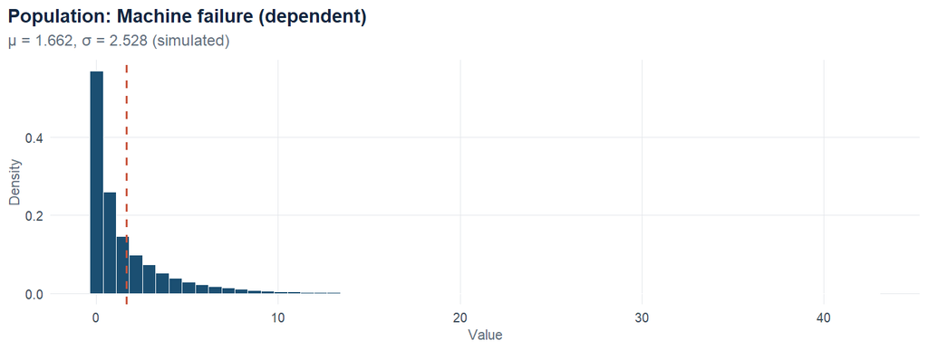

Figure 68: Population distribution for Machine failure (dependent) (50,000 simulated draws). The dashed line marks the mean.

```r
plot_population("rdependent")
```

### 3.11.2 Convergence of the Mean, Median, Skewness and Kurtosis

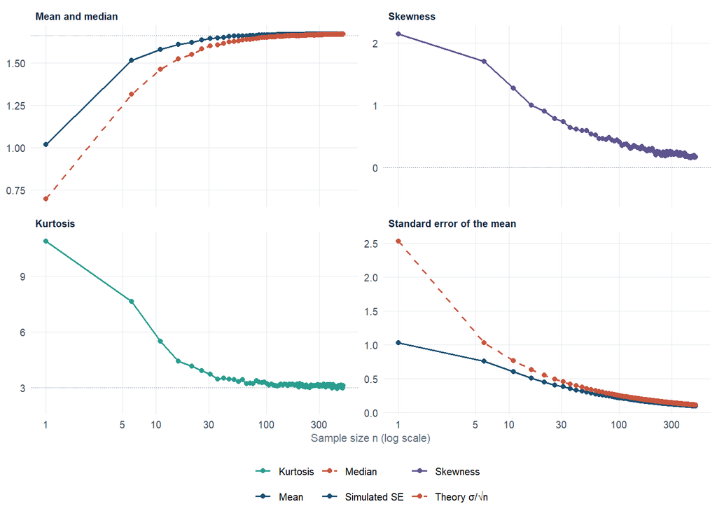

```r
plot_convergence("rdependent")
```

Kurtosis is within tolerance at n - 27. Skewness is within tolerance at n = 66. At n = 66, the median is within 0.5 of the mean and the standard deviation is within 0.5 of the theoretical standard error as well.

### 3.11.3 Histograms and Q–Q Plots

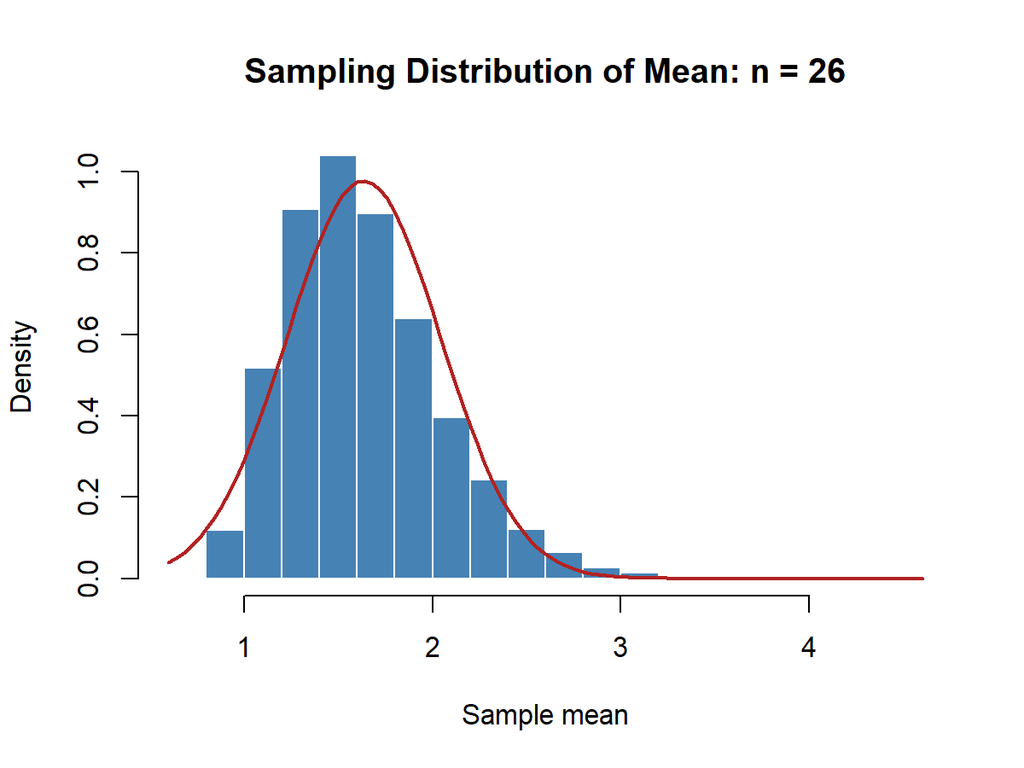

Figure 70: Histogram (left) and normal Q–Q plot (right) of the sample means at selected n.

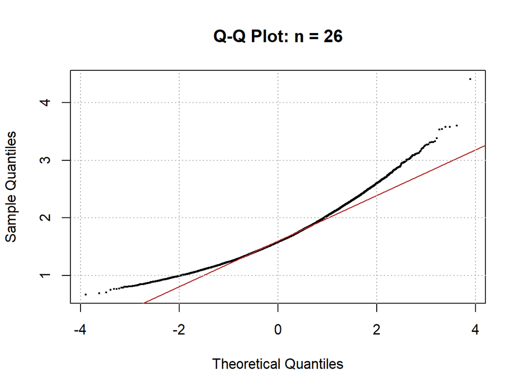

Figure 71: Histogram (left) and normal Q–Q plot (right) of the sample means at selected n.

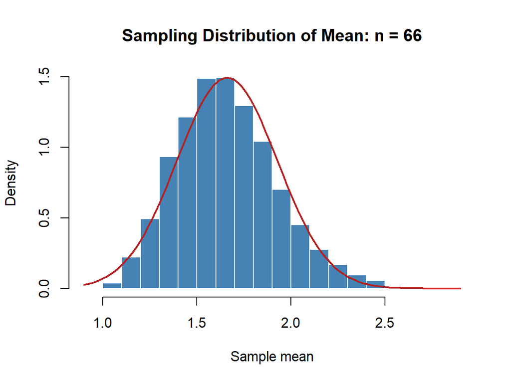

Figure 72: Histogram (left) and normal Q–Q plot (right) of the sample means at selected n.

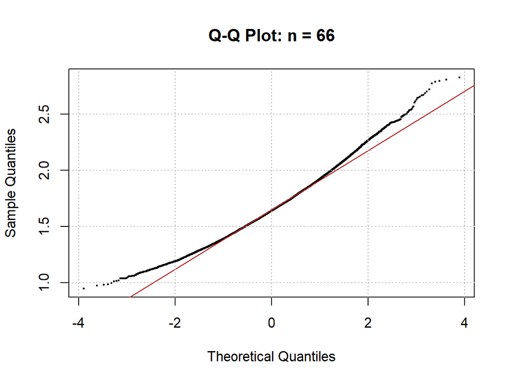

Figure 73: Histogram (left) and normal Q–Q plot (right) of the sample means at selected n.

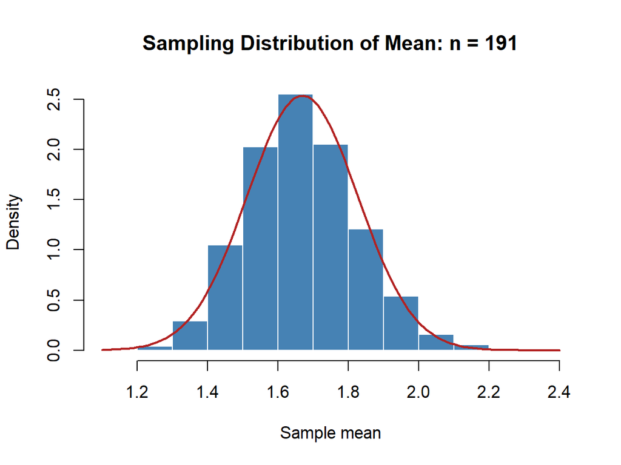

Figure 74: Histogram (left) and normal Q–Q plot (right) of the sample means at selected n.

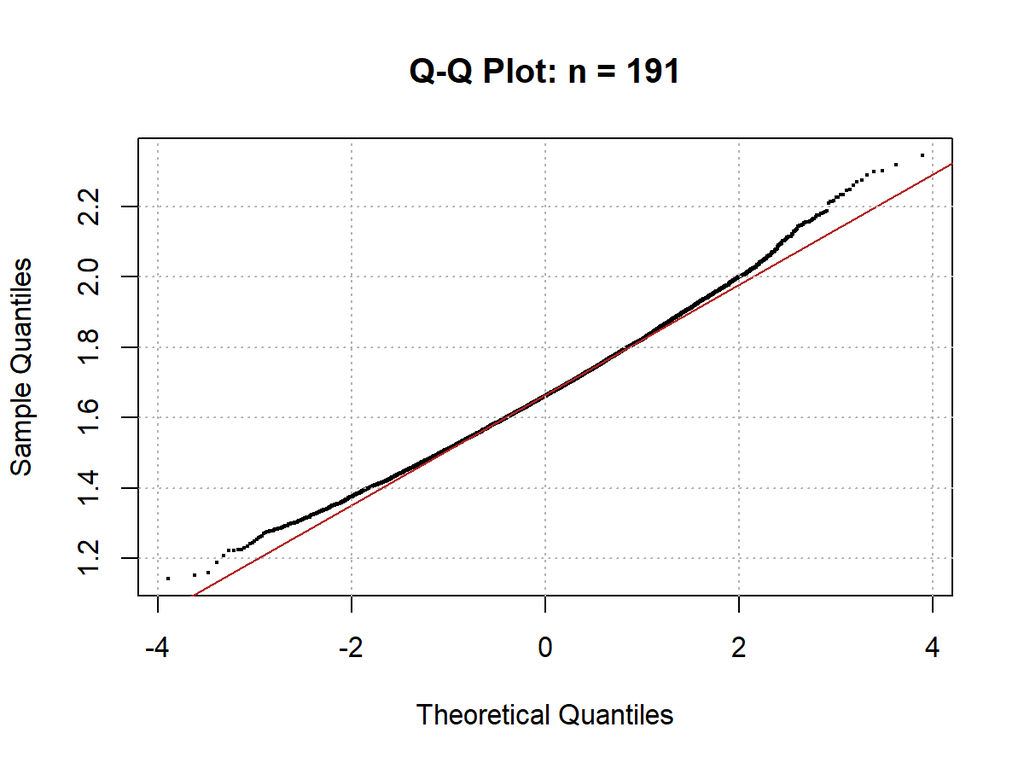

Figure 75: Histogram (left) and normal Q–Q plot (right) of the sample means at selected n.

```r
show_hist_qq("rdependent")
```

Q-Q plot show the distribution data is slowly converging toward the normal line. Close approximate occured around n ~ 190. The right tail end takes a while longer (n ~ 400) to stabilize on the Q-Q line.

### 3.11.4 Formal Test Results

```r
stats_table("rdependent")
```

Table 14: Normality diagnostics for Machine failure (dependent) at the selected n.

| n | Mean | SD (sim. SE) | Skew | Kurt | Shapiro–Wilk W | Shapiro–Wilk p | Lilliefors (KS) D | Lilliefors (KS) p | Anderson–Darling A | Anderson–Darling p | D'Agostino–Pearson χ² | D'Agostino–Pearson p |
| --- | --- | --- | --- | --- | --- | --- | --- | --- | --- | --- | --- | --- |
| 26 | 1.635 | 0.408 | 0.789 | 3.912 | 0.9653 | <0.001 | 0.0567 | <0.001 | 72.971 | <0.001 | 990.094 | <0.001 |
| 66 | 1.660 | 0.267 | 0.466 | 3.221 | 0.9891 | <0.001 | 0.0307 | <0.001 | 24.541 | <0.001 | 346.291 | <0.001 |
| 191 | 1.669 | 0.157 | 0.277 | 3.180 | 0.9947 | <0.001 | 0.0196 | <0.001 | 7.553 | <0.001 | 135.155 | <0.001 |
| 201 | 1.669 | 0.154 | 0.307 | 3.209 | 0.9954 | <0.001 | 0.0222 | <0.001 | 10.738 | <0.001 | 165.857 | <0.001 |
| 401 | 1.672 | 0.109 | 0.206 | 3.155 | 0.9977 | <0.001 | 0.0135 | <0.001 | 4.503 | <0.001 | 78.518 | <0.001 |

**Discussion** The classical CLT requires independence, but versions of the CLT exist for dependent data. They require (1) short memory, meaning the dependence dies off quickly, (2) finite variance, and (3) stationary or convergence to a stationary distribution. Long-memory processes, where auto correlations decay slowly (Hurst exponent $H > 0.5$), fail these conditions because the SD of the sample mean shrinks more slowly than $1/\sqrt{n}$.*

This process is expected to satisfy all three conditions:

- **Finite variance and light tails.** For $x \ge 0$, the rate is at least $e^{-1.25} \approx 0.29$, so every operating time is stochastically dominated by an Exponential(0.29) variable. All moments are therefore finite, unlike the Cauchy case.
- **Short memory.** A long operating time produces a very large next rate and hence a very short next time, and vice versa. The chain forgets its past quickly, so the dependence should decay geometrically.
- **Negative dependence.** The same feedback (long time, then short time) suggests a clearly negative lag-1 autocorrelation.

The CLT hold and the sampling distribution of the mean should become approximately normal, but at a very large n.

The exact n is a little unsure. The moment and the Shapiro and KS-test all point to a smaller n, relative to the visual Q-Q visual test. Future improvement could consider adding metrics to measure how much deviation from the Q-Q plot line is the distribution data. For current analysis, the more conservative n = 191 was chosen from the graphical visual.

**NoteDependent machine failure distribution: n = 191 from graphical test.**

## 3.12 Basketball shots (non-identical)

### 3.12.1 Description

One observation is the number of shots made in a 20-shot game. Shot $i$ is an independent Bernoulli($p_i$) trial, with $p_i$ falling linearly from 0.90 (shot 1) to 0.50 (shot 20), so the shots within a game are non-identically distributed.

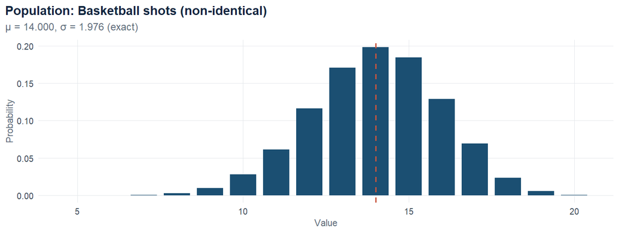

```r
plot_population("rnonidentical")
```

### 3.12.2 Convergence of the Mean, Median, Skewness and Kurtosis

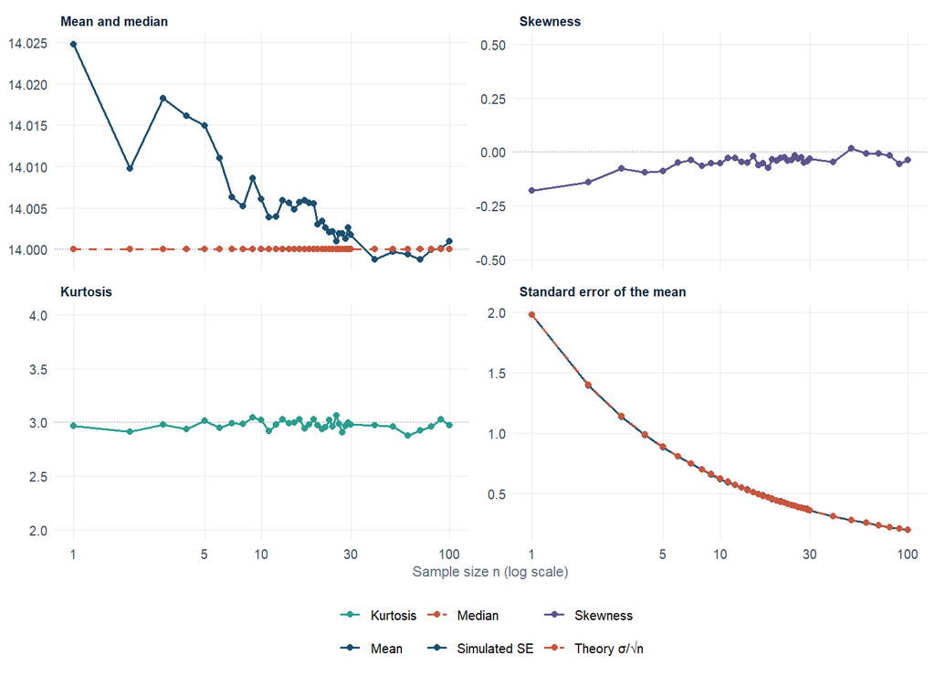

```r
plot_convergence("rnonidentical")
```

Moment statistics are within the tolerance, even at small n

### 3.12.3 Histograms and Q–Q Plots

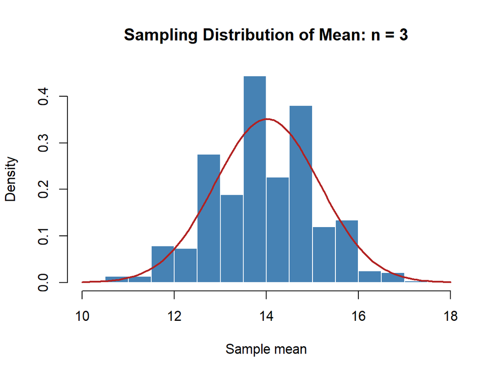

Figure 78: Histogram (left) and normal Q–Q plot (right) of the sample means at selected n.

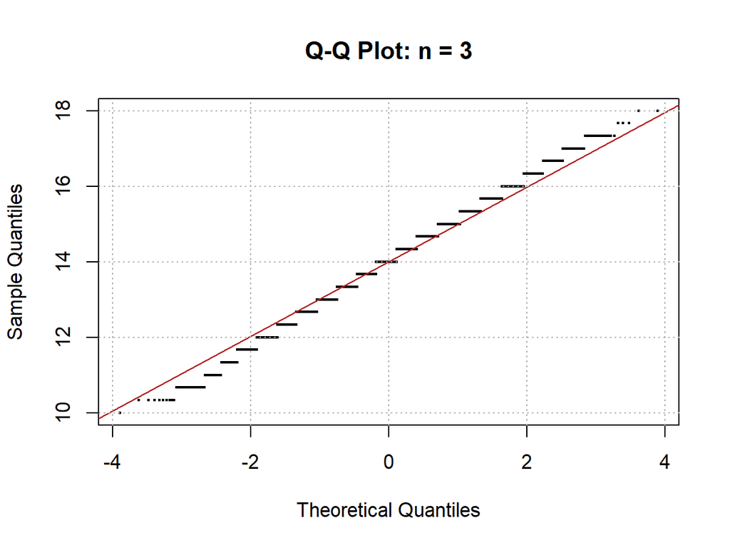

Figure 79: Histogram (left) and normal Q–Q plot (right) of the sample means at selected n.

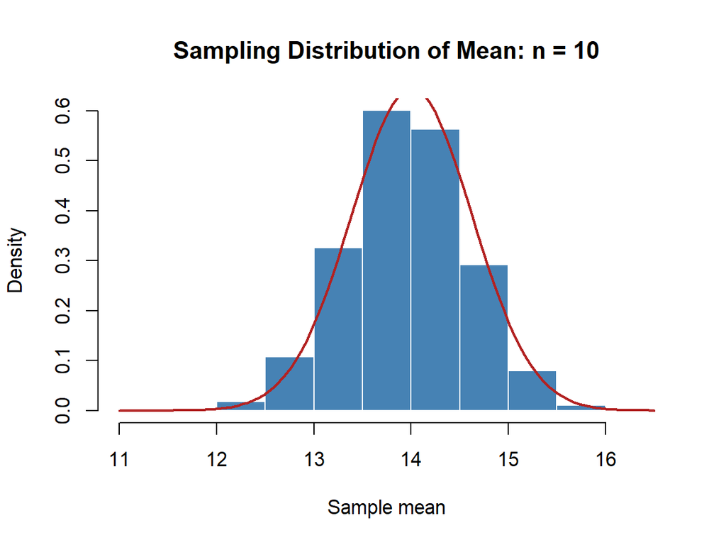

Figure 80: Histogram (left) and normal Q–Q plot (right) of the sample means at selected n.

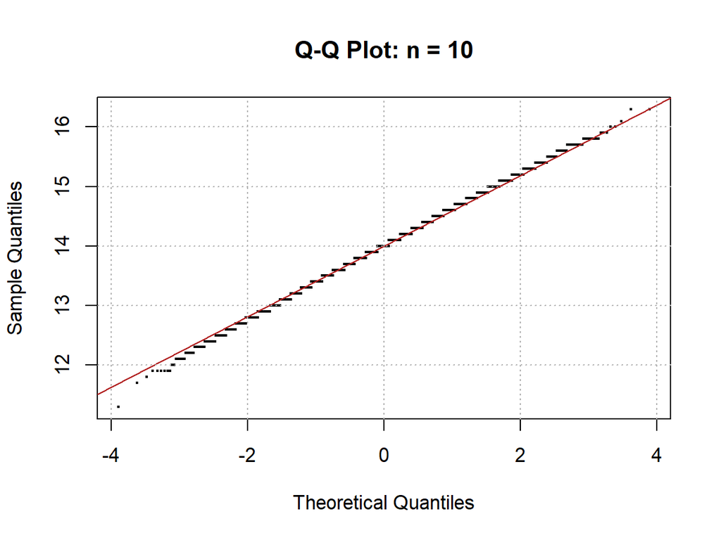

Figure 81: Histogram (left) and normal Q–Q plot (right) of the sample means at selected n.

```r
show_hist_qq("rnonidentical")
```

At low n, the discrete data points are noticeably deviated from the normal line. Data start to converge around n = 10.

### 3.12.4 Formal Test Results

```r
stats_table("rnonidentical")
```

Table 15: Normality diagnostics for Basketball shots (non-identical) at the selected n.

| n | Mean | SD (sim. SE) | Skew | Kurt | Shapiro–Wilk W | Shapiro–Wilk p | Lilliefors (KS) D | Lilliefors (KS) p | Anderson–Darling A | Anderson–Darling p | D'Agostino–Pearson χ² | D'Agostino–Pearson p |
| --- | --- | --- | --- | --- | --- | --- | --- | --- | --- | --- | --- | --- |
| 1 | 14.025 | 1.979 | −0.179 | 2.966 | 0.9763 | <0.001 | 0.1116 | <0.001 | 106.188 | <0.001 | 53.249 | <0.001 |
| 3 | 14.018 | 1.135 | −0.076 | 2.978 | 0.9921 | <0.001 | 0.0658 | <0.001 | 35.843 | <0.001 | 9.665 | 0.008 |
| 10 | 14.006 | 0.619 | −0.053 | 3.022 | 0.9976 | <0.001 | 0.0371 | <0.001 | 11.015 | <0.001 | 4.960 | 0.084 |
| 20 | 14.003 | 0.442 | −0.042 | 2.973 | 0.9987 | <0.001 | 0.0271 | <0.001 | 5.458 | <0.001 | 3.220 | 0.200 |

W statistic is within tolerance at n = 3. The Chi square statistic is within tolerance at n = 10

**Discussion** The generator returns `n` game totals, and the sample mean averages those `n` totals. Each game is a fresh, independent draw from the same distribution (a Poisson-binomial), so the averaged observations are independent and identically distributed. The non-identical structure sits inside each observation, not across the observations being averaged. The exact moments of one game are:*

- *Mean $\mu = \sum p_i = 14$ shots.*
- *Variance $\sigma^2 = \sum p_i(1-p_i) \approx 3.905$, so $\sigma \approx 1.976$*
- *Skewness $\approx -0.17$ and excess kurtosis $\approx -0.06$. A single game is close to normal, with a slight left skew*

*Contrast with a genuinely non-identical average.* If the quantity averaged were the individual shots, $X_i \sim \text{Bernoulli}(p_i)$ with different $p_i$, the observations would be independent but not identically distributed. The classical CLT would not apply as stated, but the Lindeberg-Feller CLT would, since each shot is bounded and the total variance $\sum p_i(1-p_i)$ grows without bound as shots are added. The standardization then uses $\sqrt{\sum p_i(1-p_i)}$ instead of $\sigma\sqrt{n}$, and the mean of the average is $\bar{p}$, not a common $\mu$. The CLT therefore still holds for non-identical independent observations when no single observation dominates the variance. The CLT can fail only if the variances are so unbalanced that one term dominates, or if the variances are infinite.

**NoteBasketball shots (non-identical): n = 10 from the graphical and X^2 test**

# 4 Conclusion

## 4.1 Is n = 30 a Universal Rule?

The value for n depends on the population distribution. However, I was surprised some distribution resulted in a a normal sample distribution quite fast. For many distribution, the center of the sample distribution is approximately normal, per the moment and W statistics. However, the tail shows noticeable and/or significant deviations, requiring a larger n to adequately approx the distribution as normal.

## 4.2 Limitations

The Cauchy distribution violates these conditions: its mean is undefined and its variance is not finite. Consequently, the sample mean does not stabilize around a population mean and its sampling distribution does not converge to a normal distribution as $n$ increases.

Independence and identical distribution are also assumptions of the classical CLT, but they can be relaxed under more advanced versions of the theorem. For example, normal convergence may still occur when observations are weakly dependent or not identically distributed, provided additional conditions control the dependence structure and the contribution of individual observations. Violating them may change the rate of convergence or prevent convergence to a normal distribution, depending on the specific model.

## 5 Appendix

## 5.1 Scripts

**Notesetup.R**

```r
# Install package ==============================================================
required_packages <- c(
  "moments",
  "nortest",
  "fBasics",
  "ggplot2",
  "gt",
  "scales",
  "dplyr"
)

for (pkg in required_packages) {
  if (!requireNamespace(pkg, quietly = TRUE)) {
    install.packages(
      pkg,
      repos = "https://cloud.r-project.org"
    )
  }
}
```

**Notescripts/config.R**

```r
# Set random seed ==============================================================
STUDENT_ID <- 0348
```

**Notescripts/distribution_generators.R**

```r
## Dependent Exponential Process: Modeling Machine Failures ====================
n <- 1000
failure_time <- numeric(n)
failure_rate <- numeric(n)

# Model parameters
baseline_rate <- 1
beta <- 1.25
reference_time <- 1

# Generate the first operating time
failure_rate[1] <- baseline_rate
failure_time[1] <- rexp(1, rate = failure_rate[1])

# Generate the remaining dependent operating times
for (t in 2:n) {
  failure_rate[t] <- baseline_rate *
    exp(beta * (failure_time[t - 1] - reference_time))

  failure_time[t] <- rexp(1, rate = failure_rate[t])
}

# Creates the distribution data table
dependent_distribution <- data.frame(
  failure = 1:n,
  operating_time = failure_time,
  failure_rate = failure_rate
)


## Basketball: Non-Identically Distributed Observations ========================
# Linear sequence to decrease the probability from 0.90 at shot #1 to 0.50 at shot #20
n_games <- 1000
n_shots <- 20
shot_number <- 1:n_shots

p <- seq(from = 0.90, to = 0.50, length.out = n_shots)

# Create the probability data table
data.frame(
  shot = shot_number,
  probability = round(p, 3)
)

# Simulate 1 game using binomial w/ the custom probability: whether or not he made each shot in the game
game_simulation <- function() {
  made <- rbinom(n = n_shots, size = 1, prob = p)      #Create a table of bernoulli results

  one_game <- data.frame(
  shot = shot_number,
  probability = round(p, 3),
  made = made
  )

  return(sum(made))                                    #return the total # shot made in the game by summing the 1s (success)
}

## Custom Age-at-Death Distribution ============================================
# Define age:
age <- 0:100

# Construct components
early_component <- 0.045 * exp(-age / 5)                     #exponential decay
adult_component <- 0.030 * exp(-0.5 * ((age - 65) / 10)^2)   #normal density curve

# Combine and normalize the components
weight <- early_component + adult_component                  #Add the two components
probability <- weight / sum(weight)                          #Convert the weights into P
percent <- 100 * probability                                 #Convert probabilities into %

sum(probability)                                             #Sanity check
sum(percent)

# Create the distribution data frame
death_distribution <- data.frame(
  age = age,
  probability = probability,
  percent = percent
)
```

**Notescripts/distributions.R**

```r
source("scripts/distribution_generators.R")

# 1. Standard Normal: mean = 0, standard deviation = 1
dist_normal <- list(
  normal = function(m) {
    rnorm(m, mean = 0, sd = 1)
  }
)


# 2. Continuous Uniform: from 0 to 1
dist_uniform <- list(
  uniform = function(m) {
    runif(n = m, min = 0, max = 1)
  }
)


# 3. Six-sided die: values 1 through 6
dist_die <-list(
  die = function(m) {
    sample(x = 1:6, size = m, replace = TRUE)
  }
)


# 4. Exponential: rate lambda = 1
dist_exponential <- list(
  exponential = function(m) {
    rexp(m, rate = 1)
  }
)


# 5. Poisson: lambda = 1
dist_poisson <- list (
  poisson = function(m) {
    rpois(m, lambda = 1)
  }
)


# 6. Small Binomial: n = 5, p = 0.10
dist_binom_small <- list (
  binomial_small = function(m) {
    rbinom(m, size = 5, prob = 0.10)
  }
)


# 7. Large Binomial: n = 20, p = 0.50
dist_binom_large <- list (
  binomial_large = function(m) {
    rbinom(m, size = 20, prob = 0.50)
  }
)


# 8. Cauchy: location = 0, scale = 1
dist_cauchy <- list (
  cauchy = function(m) {
    rcauchy(m, location = 0, scale = 1)
  }
)


#9. Machine Failure: Dependent distribution
dist_dependent <- list(
  rdependent = function(n) {

    # Result array
    failure_time <- numeric(n)
    failure_rate <- numeric(n)

    # Model parameters
    baseline_rate <- 1
    beta <- 1.25
    reference_time <- 1

    # Generate the first operating time
    failure_rate[1] <- baseline_rate
    failure_time[1] <- rexp(1, rate = failure_rate[1])

    # Generate the remaining dependent operating times
    if (n >= 2) {
      for (t in 2:n) {
        failure_rate[t] <- baseline_rate *
          exp(beta * (failure_time[t - 1] - reference_time))

        failure_time[t] <- rexp(
          1,
          rate = failure_rate[t]
        )
      }
    }

    # Return the observations to be averaged
    return(failure_time)
  }
)


# 10. Basketball: Non-identical Bernoulli distributed observations
dist_nonidentical <- list(
  rnonidentical = function(n) {

    shot_results <- matrix(
      rbinom(
        n = n * n_shots,
        size = 1,
        prob = rep(p, times = n)
      ),
      nrow = n_shots,
      ncol = n
    )

    colSums(shot_results)
  }
)

#11. A Custom Age-at-Death Distribution
dist_death <- list (
    rdeath = function(n) {
      sample(
        x = death_distribution$age,
        size = n,
        replace = TRUE,
        prob = death_distribution$probability
      )
    }
)


# #9. Dependent distribution
# dist_dependent <- list (
#   rdependent = function(n) {
#     sample(
#       x = dependent_distribution$failure,
#       size = n,
#       replace = TRUE,
#       prob = dependent_distribution$failure_rate
#     )
#   }
# )


# distributions_6 <- list (
#   #10. Basketball - Non-Identically Distributed Observations
#   rnonidentical = function(n) {
#     replicate(n, game_simulation())
#   }
# )


# # 10. Non-identical Bernoulli observations w/ each observation has a different probability p
# nonidentical_bernoulli = function(m) {
#   p_values <- seq(0.5, 0.9, length.out = m)
#   rbinom(m, size = 1, prob = p_values)
# }
```

**Notescripts/main.R**

```r
## Library =====================================================================
library(moments)
library(nortest)
library(fBasics)
source("scripts/config.R")
set.seed(STUDENT_ID)
source("scripts/distributions.R")


## Constants and Settings ======================================================
# Simulation parameters:
R <- 10000                    #Num of Monte Carlo repetition

# Theoretical values:
skew_norm <- 0                #skewness of normal dist = 0
kurtosis_norm <- 3            #proper kurtosis of norm dist = 3

# Stats to calculate:
stats_col = c("n",
              "Mean",
              "Median",
              "SD",
              "Theo_SE",
              "Skewness",
              "SE_skew",
              "Z_skew",
              "Kurtosis",
              "SE_kurt",
              "Z_kurt",
              "SW_W",
              "SW_p",
              "Lillie_D",
              "Lillie_p",
              "AD_A",
              "AD_p",
              "DP_Chi2",
              "DP_p"
)


## Simulation Function =========================================================
run_simulation <- function(
    r_generator,                                            #random generator
    distribution_name,                                      #name for labels
    n,                                                      #no of sampling amount
    R,                                                      #no of MC simulation
    stats_col                                               #columns to store the stats
) {

  #Data files and table to save results: ---------------------------------------
  fig_dir <- file.path("results", "figures")
  dir.create(fig_dir, showWarnings = FALSE, recursive = TRUE)

  save_png <- function(name, kind, n, plot_fun) {
    png(file.path(fig_dir, sprintf("%s_%s_n%d.png", name, kind, n)),
        width = 1200, height = 900, res = 200)
    plot_fun()
    dev.off()
  }

    pdf_path <- file.path(
    "results",
    paste0("normality_plots_", distribution_name, ".pdf")
  )

  pdf(pdf_path)
  on.exit(dev.off(), add = TRUE)


  csv_path <- file.path(
    "results",
    paste0("stats_results_", distribution_name, ".csv")
  )

  stats <- matrix(
    NA_real_,
    nrow = length(n),
    ncol = length(stats_col),
    dimnames = list(NULL, stats_col)
  )

  #Monte Carlo (MC) Simulation: ------------------------------------------------
  par(mfrow = c(3, 2))                                        #Set the subplot layout

  for (j in seq_along(n)) {

    #Run the MC R times for each n sample
    set.seed(STUDENT_ID)                                      #Reset seed for each simulation
    i <- n[j]
    sample_means <- replicate(
      R,
      {
        one_sample <- r_generator(i)

        if (length(one_sample) != i) {
          stop(
            paste(distribution_name, "generator returned", length(one_sample), "points instead of", i)
          )
        }

        mean(one_sample)
      }
    )

    #Calculate Simulation Statistics -------------------------------------------
    # 1 Descriptive
    mc_mean <- mean(sample_means)
    mc_median <- median(sample_means)
    mc_sd <- sd(sample_means)
    theo_se <- mc_sd / sqrt(i)

    # 2. Skewness
    mc_skew <- moments::skewness(sample_means)
    mc_skew_se <- sqrt(6 / R)
    mc_skew_z <- (mc_skew - skew_norm) / mc_skew_se

    # 3. Pearson kurtosis
    mc_kurtosis <- moments::kurtosis(sample_means)
    mc_kurtosis_se <- sqrt(24 / R)
    mc_kurtosis_z <- (mc_kurtosis - kurtosis_norm) / mc_kurtosis_se

    # 4. Shapiro-Wilk: R accepts a maximum of 5,000 observations
    sw_data <- sample(sample_means, size = min(length(sample_means), 5000), replace = FALSE)
    shapiro_result <- stats::shapiro.test(sw_data)
    sw_stat <- unname(shapiro_result$statistic)
    sw_p <- shapiro_result$p.value

    # 5. Lilliefors-corrected Kolmogorov-Smirnov test
    lillie_result <- nortest::lillie.test(sample_means)
    lillie_stat <- unname(lillie_result$statistic)
    lillie_p <- lillie_result$p.value

    # 6. Anderson-Darling test
    ad_result <- nortest::ad.test(sample_means)
    ad_stat <- unname(ad_result$statistic)
    ad_p <- ad_result$p.value

    # 7. D'Agostino-Pearson omnibus test
    dp_result <- fBasics::dagoTest(sample_means)
    dp_stat <- unname(dp_result@test$statistic[1])
    dp_p <- dp_result@test$p.value[1]

    #Store the statistics results ----------------------------------------------
    stats[j, ] <- c(
      i,
      round(mc_mean, 5),
      round(mc_median, 5),
      round(mc_sd, 5),
      round(theo_se, 5),
      round(mc_skew, 3),
      round(mc_skew_se, 3),
      round(mc_skew_z,3),
      round(mc_kurtosis, 3),
      round(mc_kurtosis_se, 3),
      round(mc_kurtosis_z, 3),
      round(sw_stat, 5),
      sw_p,
      round(lillie_stat, 5),
      lillie_p,
      round(ad_stat, 5),
      ad_p,
      round(dp_stat, 5),
      dp_p
    )

    #Draw graphical results ----------------------------------------------------
    # Histogram
    hist(
      sample_means,                                          #The data
      probability = TRUE,                                    #Density hist rather than freq hist
      col = "steelblue",                                     #Fill color
      border = "white",                                      #Border color
      main = paste("Sampling Distribution of Mean: n =", i), #Title
      xlab = "Sample mean"                                   #x-axis label
    )

    curve(dnorm(x, mean = mc_mean, sd = mc_sd), add = TRUE, col = "firebrick", lwd = 2)

    # Q-Q
    qqnorm(
      sample_means,
      main = paste("Q-Q Plot: n =", i),
      pch = 46,
      cex = 0.5
    )
    qqline(sample_means, col = "firebrick")

    grid(nx = NULL, ny = NULL, lty = 3, col = "gray70")  #dotted grid line

    #Export the individual graphical results as png-------------------------------
    save_png(distribution_name, "hist", i, function() {
      hist(sample_means, probability = TRUE, col = "steelblue", border = "white",
           main = paste("Sampling Distribution of Mean: n =", i), xlab = "Sample mean")
      curve(dnorm(x, mean = mc_mean, sd = mc_sd), add = TRUE, col = "firebrick", lwd = 2)
    })
    save_png(distribution_name, "qq", i, function() {
      qqnorm(sample_means, main = paste("Q-Q Plot: n =", i), pch = 46, cex = 2)
      qqline(sample_means, col = "firebrick")
      grid(nx = NULL, ny = NULL, lty = 3, col = "gray70")  #dotted grid line
    })

  }

  # Summary of Statistics Plots ================================================
  # Reset layout
  par(mfrow = c(3, 1))

  # Mean, Median
  matplot(                                                          #Std R plot tool
    x = stats[, "n"],                                               #--> Select the values in the "n" col for x-axis
    y = stats[, c("Mean", "Median")],                   #--> Select the stats cols for y-axis
    type = "o",                                                     #--> plot point + line
    pch = 1:2,                                                      #--> plotting char = 4 symbols for each stats
    lty = 1,                                                        #--> line type = 1 line type
    lwd = 2,                                                        #--> line width
    col = c("steelblue", "darkgreen"),                 #--> color
    xlab = "Sample size, n",
    ylab = "Statistic value",
    main = "Mean and Median versus Sample Size (n)"
  )
  legend(
    "top",
    legend = c("Mean", "Median"),
    col = c("steelblue", "darkgreen"),
    pch = 1:2,
    lty = 1,
    lwd = 2
  )
  grid()                                                            #--> turn on grid
  abline(h = 0, lty = 2, col = "gold")                              #--> draw horizontal line

  # Plot Skewness
  plot(
    stats[, "n"],
    stats[, "Skewness"],
    type = "o",
    pch = 3,
    lwd = 2,
    col = "firebrick",
    xlab = "Sample size, n",
    ylab = "Skewness",
    main = "Skewness versus Sample Size (n)"
  )
  grid()
  abline(h = 0, lty = 2, col = "gold")

  # Plot Kurtosis
  plot(
    stats[, "n"],
    stats[, "Kurtosis"],
    type = "o",
    pch = 4,
    lwd = 2,
    col = "purple",
    xlab = "Sample size, n",
    ylab = "Kurtosis",
    main = "Kurtosis versus Sample Size (n)"
  )
  grid()
  abline(h = 3, lty = 2, col = "gold")

  # Export the statistics table ------------------------------------------------
  write.csv(stats, file = csv_path, row.names = FALSE)

  invisible(stats)

}

# Run every distribution -------------------------------------------------------
all_stats <- list()
run_distributions <- c(
  dist_nonidentical
)

n <- c(
  seq(1, 30, by = 1) ,      #Num of sample size needed to satisfy CLT
  seq(40, 100, by = 10)
  )

for (distribution_name in names(run_distributions)) {
  message("Running: ", distribution_name)

  all_stats[[distribution_name]] <- run_simulation(
    r_generator = run_distributions[[distribution_name]],
    distribution_name = distribution_name,
    n = n,
    R = R,
    stats_col = stats_col
  )
}
```

## 5.2 Results Folder

| File type | Count | Location |
| --- | --- | --- |
| Statistics tables (CSV) | 11 | `results/stats_results_<name>.csv` |
| Diagnostic plot books (PDF) | 11 | `results/normality_plots_<name>.pdf` |
| Histogram and Q-Q figures (PNG) | 1428 | `results/figures/<name>_hist_n<n>.png`, `<name>_qq_n<n>.png` |

## 5.3 AI Prompts for This Project

- I was having trouble understanding what I needed to sample for the three custom distributions. This is one example of the AI prompt I used.

  **Prompt**: Here is the code provided by my professor on a dependent distribution machine failure. What should I sample and average to test the CLT based on this document? **AI response**:

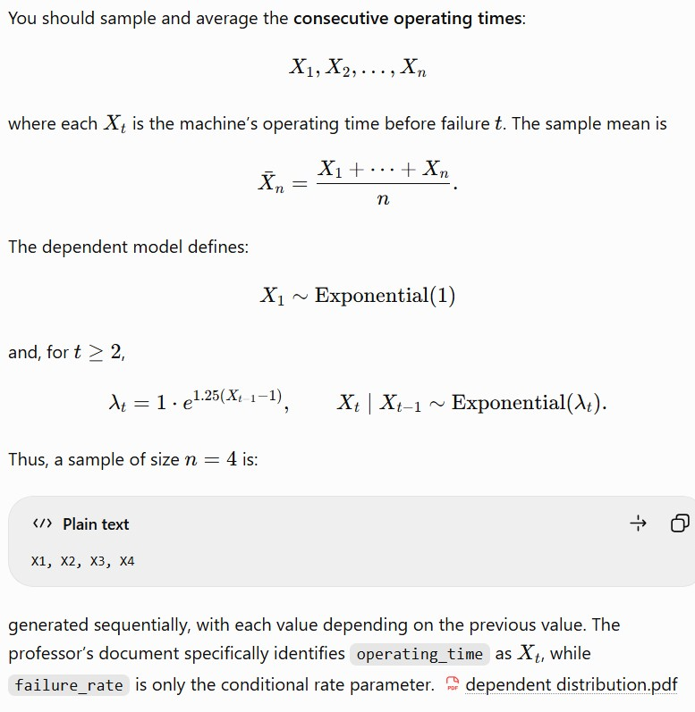

AI response to setting up the sampling of the custom distribution

```r
knitr::include_graphics("images/AI-Prompt-Dependent-Distribution.jpg")
```

**Followup**: how to put the new rdependent function into my automation structure **AI response**

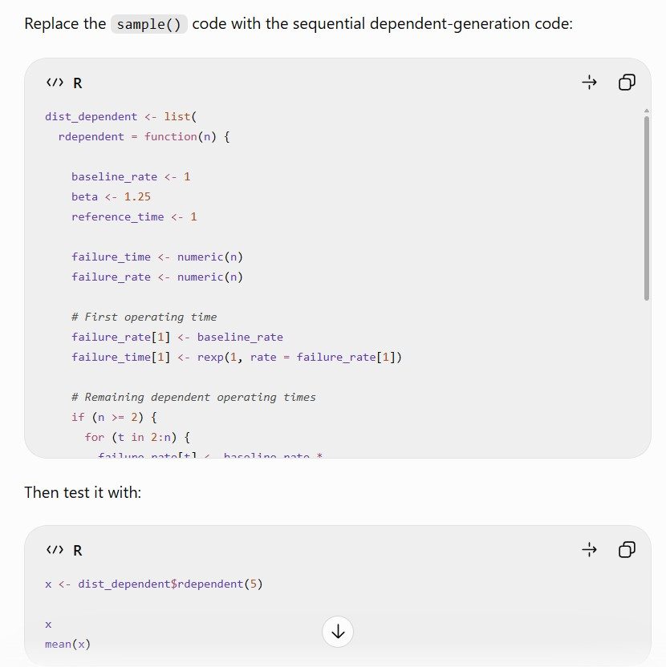

AI response to setting up the sampling of the custom distribution

```r
knitr::include_graphics("images/AI-Prompt-Dependent-Distribution-2.jpg")
```

## 5.4 Sources

- https://pmc.ncbi.nlm.nih.gov/articles/PMC3591587/
- https://statisticsfundamentals.com/descriptive-statistics/skewness-and-kurtosis/
- https://statisticsfundamentals.com/tables/anderson-darling-table/
- https://lean6sigmahub.com/how-to-perform-the-shapiro-wilk-test-a-complete-guide-to-testing-data-normality/
- https://www.sciencedirect.com/science/chapter/edited-volume/abs/pii/B978012813543300007X
- https://www.clinicalbiostats.com/tables/shapiro-wilk-test-table/
- https://www.statology.org/central-limit-theorem-conditions/
- http://www.ledoit.net/TimCrack_CLT_Dependent_JFEduc_2010.pdf
- https://link.springer.com/chapter/10.1007/978-0-387-75971-5_9
- https://www.youtube.com/watch?v=HD_5oWP2cf0&t=25s
- https://statisticsbyjim.com/graphs/qq-plot/#google_vignette
- https://pmc.ncbi.nlm.nih.gov/articles/PMC3693611/
- https://pmc.ncbi.nlm.nih.gov/articles/PMC3693611/
- https://vrcacademy.com/tutorials/cauchy-distribution/
- https://link.springer.com/chapter/10.1007/978-0-387-75971-5_9

## 5.5 Future improvements

- Adding metrics to more objectively judge the Q-Q plot
- Adding citations. However, all sources are listed in the appendix.